# General Autonomy for Industry 2.0

Pitch Deck

Abhishek Gupta

Associate Professor, ECE, The Ohio State University

Founder, Rewardwise & Ensemble Control Inc.

Project Aegis

Scaling RL-Driven Robotics

Abhishek Gupta, PhD

abhishek.gupta@aegis.ai

The Ohio State University

We make Physical AI composable and fault-tolerant

## Problem

General purpose robots are being developed for standalone operations

Industry 2.0 needs them to collaborate to carry out tens of missions everyday Any planning system should be fault tolerant to unknown unknowns and even better. Be activrly resilient to them

## Solution

By using cooperative game theory and decentralized Physical AI, we make it fault tolerant

## Earned Secret

Coordination is a bigger problem

- Communication bottlenecks and dropouts
- Deadzones in 1M sq. ft warehouse

Coordination is where failure happens

Option A: The Loop Speed Secret “The industry is obsessed with ‘World Models’ and high-level planning. The secret? Dexterity isn’t a planning problem; it’s a latency problem. By moving the ‘intelligence’ from the 10Hz planning layer directly into the 500Hz torque-control loop, we achieve human-like reaction speeds that ‘smarter’ robots simply can’t match.”

Option B: The Generalization Secret “Everyone is trying to solve robotics with ‘More Data.’ We’ve learned that data without Control-Theoretic Constraints is just noise. The secret to 99.9% reliability isn’t a bigger transformer; it’s an architecture that treats the Neural Network as a dynamic feedback element, not a static path generator.”

## Leadership & Advisory Board

### Founder & CEO

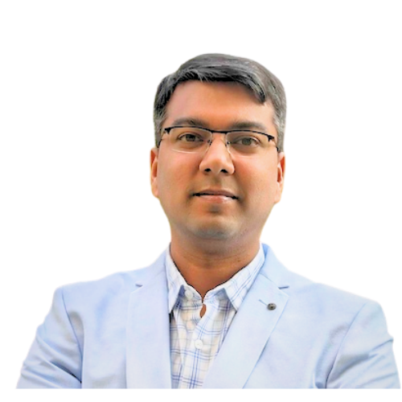

**Abhishek Gupta, PhD**

*Associate Professor, The Ohio State University*

- **Expertise:** Reinforcement Learning, Control Theory, & Stochastic Systems.
- **Background:** PhD from UIUC; Postdoc from UC Berkeley, Stanford and USC; Founder of Ensemble Control Inc.
- **Vision:** Bridging the gap between high-fidelity simulation and real-world robotic dexterity.

### Strategic Advisory Board

**Prof. Kannan Athreya** *Technical Advisor*

Expert in joint sensing and communication.